# FSU_plyr_dplyr_session

Cody Flagg

Thursday, April 16, 2015

# Outline

1. The Split-Apply-Combine (SAC) Approach
2. Data Wrangling with plyr - merging multiple files in a directory
- The `for loop` method
- The `plyr` method
3. Data Wrangling with plyr - splitting a data frame into multiple files
4. Data Quality Assurance (QA) with plyr
- A contractor debacle example

### Libraries

```r
# libraries used
# if you don't have these, run: install.packages(c("plyr","dplyr","stringer","knitr"))
library(plyr)
library(dplyr)
library(stringr)
library(knitr)
```

## 1. The Split-Apply-Combine (SAC) Approach

[figure not shown]

### plyr() grammar

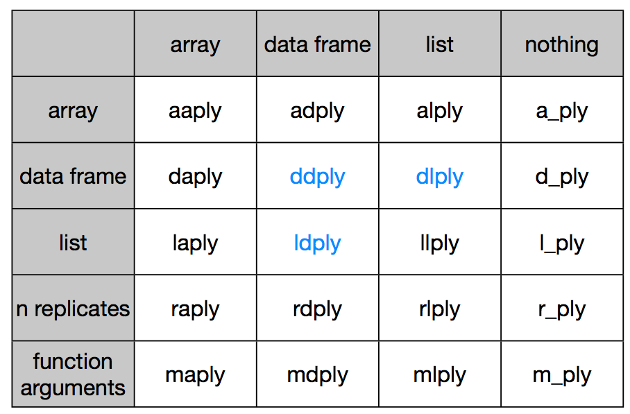

### Why vectorize (i.e. plyr, apply) your code over looping?

The code is cleaner (once youâre familiar with the concept). The code can be easier to code and read, and less error prone because:

1. you do not have to deal with subsetting
2. you do not have to deal with saving your results
2. Apply functions can be faster than for loops, sometimes dramatically

### plyr vs. base-R apply functions

1. plyr has a common syntax â easier to remember
2. plyr requires less code since it takes care of the input and output format
3. plyr can easily be run in parallel â faster

[link](http://seananderson.ca/courses/12-plyr/plyr_2012.pdf)

## 2. Data Wrangling - merging multiple files in a directory with:

- `for loops`
- `plyr`

```r
# Set working directory and file path ... relative path will work if Git folders are in "Documents" folder
setwd("C:/Users/kjones/Documents/GitHub/codingSupportGroup/dataWrangling/plyr_session")
pathToFiles <- getwd()

#set this to the prefix for the sheets in your module; make specific to file name batch
myPrefix <- 'plotSpatialData_' # used to direct grep() to the right files, necessary if your working directory has lots of files
# mySuffix <- '.csv' # another potential variable if your directory is particularly 'busy'

# load files
fileList <- list.files(pathToFiles, full.names=TRUE) # list all the files, full.names=TRUE is necessary for ldplay/lapply to work below
fileGrab <- fileList[grep(myPrefix,fileList)] # subset to just the ones in your module, using prefix; not absolutely necessary with this folder
```

### Merge files with for loops

- *Solution 1a* : `for loop` with if/else flow control

```r
# Solution 1a: for loops with if/else nested inside
# loop through list of files defined from above, rbind() them together
for (file in fileGrab){
  if (!exists("dataset")){ # if an object named dataset does not exist, create it
    dataset <- read.csv(file, header = TRUE, sep = ",",stringsAsFactors = FALSE) # assign the first csv to "dataset"
  }

  else { # if dataset does exist, rbind() the rest of the files in the list
    temp.dataset <- read.csv(file, header=TRUE, sep=",",stringsAsFactors = FALSE) # temporary object
    dataset = rbind(dataset, temp.dataset) # final object for output
    rm(temp.dataset) # clear up workspace to free memory
  }
}
```

- Number of rows 1009
- *Solution 1b*: a cleaner `for loop` - no if/else flow control

```r
# Solution 1b: more efficient for loop; define a blank object outside the loop that is "filled" (i.e. "dataset1" here, "dataset" in Solution 1a), rather than calling it inside the loop.
# Creating the object inside a loop runs the risk of duplicating data/rows
dataset1 = NULL # blank df to "fill"
for (file in fileGrab){
  t <- read.csv(file, header = TRUE, sep = ",",stringsAsFactors = FALSE) # read the csv, assign to t
  dataset1 = rbind(t,dataset1) # bind it to the blank df
  }

nrow(dataset1) # check the number of rows
```

```
## [1] 1009
```

- *Solution 2*: the `plyr` method;

```r
# For each file in the list "fileGrab", read the .csv file to a temporary variable "t", row bind subsequent files to variable "t1", return t1 as final result
dataset2 = ldply(fileGrab, function(x){
            t <- read.csv(x, header=TRUE, sep=",",stringsAsFactors = FALSE) # read the csv
            t1 <- rbind(t) # rbind it to a temporary object
            return(t1)
}
)

nrow(dataset2) # check the number of rows
```

```
## [1] 1009
```

- *Solution 2a*: if you need to work with Excel (.xls/.xlsx) files [hidden, not evaluated]

```r
# install.packages("XLConnect")
# # read in .xlsx files, combine into a single file
# plotList.NEON = ldply(fileGrab, function(input){
#           t <- loadWorkbook(input) # load the xls file first i.e. the workbook
#           t2 <- readWorksheet(t, sheet = 1, header = TRUE) # read individual worksheets
#           t3 <- rbind(data.frame(t2)) # rbind as a data.frame
# })
```

- *Solution 3*: use data.table and lapply [hidden, not evaluated]

```r
# data.table has a reasonable built in function for this; pass the list, apply to all elements in "fileGrab", read them with fread, row bind them with rbindlist
# require(data.table)
# dataset2b  = rbindlist(lapply(fileGrab, fread))
#
# nrow(dataset2b) # check the number of rows
```

## 3. Data Wrangling with plyr - splitting a data frame into multiple files

- Using a for loop

```r
# indiciate which columns to keep e.g. only add plotID, site Type, etc.
dataset3 = dataset2[,c("domainID","siteID","plotID","plotType", "subtype", "plotSize")]

for (i in unique(dataset3$domainID)){
  fileName <- paste(i, "_plots_loop.csv")
  write.csv(dataset3[dataset3$domainID == i,], file = fileName)
  }
```

- The `plyr` method

```r
# d_ply indicates we call the function on the data frame and "discard" the results i.e. this won't return anything
# can also use dlply() for a similar result, but plyr will also return a list (of the domainIDs) as an object.
d_ply(dataset3,.(domainID), function(input)
  write.csv(input, file = paste(unique(input$domainID),"_plots_plyr.csv")))
```

- While the total “typeage” is roughly the same between the `for loop` and `plyr` methods, you do not have to worry about weird results from explicit indexing with square brackets in `plyr` or the indexing involved with nested `for loops`. The simple, straightforward syntax allows you to more quickly think about a problem to formulate a solution.
- A quick example, if we want to create a unique file for each domain plus plot type combination:

```r
# simply add plotType as another grouping variable, make sure to paste it in the file name
d_ply(dataset3,.(domainID, plotType), function(input)
  write.csv(input, file = paste(unique(input$domainID),"_",unique(input$plotType),"_plots_plyr.csv")))
```

- How would you do this with a `for loop`?
- clean-up your workspace

```r
# free up some RAM
rm(dataset, dataset1, dataset2, dataset3)
```

## 4. Data QA with plyr

- A contractor example

### Load data

- grabbing new data files for quality assurance analysis

```r
#set this to the prefix for the sheets in your module; make specific to file name batch
myPrefix<-'vst_peri'

# load and inspect files
fileGrab1 <- fileList[grep("vst_peri",fileList)] # subset to just the ones in relevant module; this was originally a list of files
azimuthFile = read.csv(fileList[grep('L_pointID',fileList)], sep = ",", stringsAsFactors=FALSE) # grab azimuths

# separate the checks into different lists - could just use a simple  vector of inputs e.g. distributedID = c(21,23,25,39,49), but this seems more flexible
pointIDList.distributed = azimuthFile[azimuthFile$plotSize == 400,]
pointIDList.tower = azimuthFile[azimuthFile$plotSize == 1600,]

azCh = azimuthFile[1:14,] # smaller chunk of azimuth set

############ Helper function - Site Name Appender - FROM FILE FIELD ################### avoid this with stringr::str_sub
# extract function from the left of string
substrLeft <- function(x,m,n){
  substr(x, m, n)
}
```

## Error Checking Function

- This function tests a few things:
1. Whether a pointID for a particular row is correct, given the type of plot (distributed, tower)
2. Whether that pointID has the correct azimuth range
- The function using matching functions to “align” data from a data frame that is outside of the function (“pointIDList…”, “azCh$aAzimuth, azCh$bazimuth”).
- The tests are carried out using a series of nested ifelse() functions
- Data matched to the outside data frame are appended to the data frame *within* the function, evaluated, and then removed (see the last line in the code)

```r
# E) Point ID and Azimuth checking function
# this just needs to point to the pointIDlist.tower data.frame, these are all 40 x 40 tower plots at the moment (1/14/2015)
# REMOVE out$Type line for data from FOPS
pointChecker.func <- function(input, ply = llply){
  ply(input, function(x){
    t <- read.csv(x, header=T, sep = ",",stringsAsFactors=FALSE) # "x" = the file name here, read it into memory, assign it to object "t"
    out <- t # a double-assignment so previous data frames are not overwritten, may be unnecessary
    out$Type <- "Tower" ####### contractor didn't add this field, so I did. They were only doing tower plots #######
    # check: if "distributed", use is.na(field) to assign value; do not use: field == "NA" else this won't work)
    out$pointIDQF <- ifelse(out$Type == "Distributed", # is it a distributed plot?
       ifelse((out$pointID %in% pointIDList.distributed$pointID),1, # if yes, compare to this list
              ifelse(is.na(out$pointID),1,-9999)),
       ifelse((out$pointID %in% pointIDList.tower$pointID),1, # if no, compare pointID to this list
              ifelse(is.na(out$pointID),1,-9999)))
    # match and append azimuth values, these are temporary columns to match against
    out$aAzimuth.ch <- azCh$aAzimuth[match(out$pointID, azCh$pointID, nomatch = NA)]
    out$bAzimuth.ch <- azCh$bAzimuth[match(out$pointID, azCh$pointID, nomatch = NA)]
    # check if stemAzimuth is in that range -
    # this convoluted code "closes the circle" since we cannot evaluate an incorrect azimuth of say "362"
    out$azimuthQF <- ifelse(out$aAzimuth.ch == 270, # does azimuth == 270?
       # if yes, the values should be between 270 and 360 OR between 0 and 90
       ifelse(out$stemAzimuth >= 270 & out$stemAzimuth <= 360 | out$stemAzimuth >= 0 & out$stemAzimuth <= 90,1,-9999),
       # if no, stem azimuth values should be between these two values and less the next two values
       ifelse(out$stemAzimuth >= out$aAzimuth.ch  & out$stemAzimuth <= out$bAzimuth.ch,1,-9999))
    out[c("aAzimuth.ch", "bAzimuth.ch","Field1")] <- list(NULL) # clean-up, remove the extra columns
      out$siteID <- substrLeft(t$plotID,1,4)
  return(out)
})
}

# execute and store output - ldply here so all of the results are in one data frame
pointCheck.output = pointChecker.func(fileGrab1, ldply)
```

### Error Checking Summary Output

```r
# summary table - summarize the errors by siteID
kable(ddply(pointCheck.output, .(siteID), summarise, # kable nicely formats output into a table
                            pointID.error = sum(na.omit(pointIDQF) == -9999),
                            azimuth.error = sum(na.omit(azimuthQF) == -9999)))
```

| siteID | pointID.error | azimuth.error |
| --- | --- | --- |
|  | 0 | 0 |
| HARV | 52 | 11 |
| OSBS | 0 | 27 |
| SCBI | 0 | 6 |

### What was flagged? pointID errors

```r
# these are the only values that pointID should be for TOWER plots:
kable(pointIDList.tower)
```

|  | plotSize | pointID | aAzimuth | bAzimuth |
| --- | --- | --- | --- | --- |
| 6 | 1600 | 21 | 0 | 90 |
| 7 | 1600 | 23 | 270 | 90 |
| 8 | 1600 | 25 | 270 | 360 |
| 9 | 1600 | 39 | 0 | 180 |
| 10 | 1600 | 41 | 0 | 360 |
| 11 | 1600 | 43 | 180 | 360 |
| 12 | 1600 | 57 | 90 | 180 |
| 13 | 1600 | 59 | 90 | 270 |
| 14 | 1600 | 61 | 180 | 270 |

```r
# the first 6 flagged rows report...
kable(head(pointCheck.output %>% # put it in a pipe! dplyr functionality
  filter(pointIDQF == -9999) %>%  # filter subsets rows
  select(plotID,pointID,pointIDQF))) # select subsets columns
```

| plotID | pointID | pointIDQF |
| --- | --- | --- |
| HARV_048 | 60 | -9999 |
| HARV_048 | 60 | -9999 |
| HARV_048 | 60 | -9999 |
| HARV_048 | 60 | -9999 |
| HARV_048 | 60 | -9999 |
| HARV_048 | 60 | -9999 |

```r
# "60" as a pointID in a tower plot
```

```r
test1 <- pointCheck.output %>% # put it in a pipe! dplyr functionality
  filter(pointIDQF == -9999) %>%  # filter subsets rows
  select(plotID,pointID,pointIDQF)



s<-pointCheck.output %>% filter(plotID=='BART_053' & grepl('Tow', Type) & pointID %in% Type)
```